# Assignment #3

### Embeding a Demand Function into an ARIMA Model:

### Dynamic Regression Laboratory.

#### (Total 40 pts.)

#### Due: Dec. 2 (before 9:00am)

The sales data is provided in CSV format in the file **“Peanut Butter Chicago.csv”**. As this is an individual skill-building assignment (as opposed to an open-ended team assignment), and I would like to achieve some degree of convergence in your answers, hence I have provided a common data preprocessing script below. The data set corresponds to the total weekly sales of peanut butter for a supermarket chain, not for the individual stores. As you can observe from the file, the data corresponds to a combination of multiple brands as well as the supermarket private label (generic) in sizes ranging from 0.75 to 1.5 lbs.

The data includes the following information for each individual stock keeping unit (SKU) as identified by its UPC code on each week in the data file:

- VEND Number identifying the product vendor (48001 corresponds to Unilever).
- UPC The product’s universal product code (bar code)
- UNITS Sales volume
- DOLLARS Dollar sales revenue
- VOL_EQ Weight in pounds of a units sold
- PPU Price per unit ($/lb)
- F Factor specifying advertising in the store weekly flyer:
  - F = “A” Large size ad.
  - F = “B” Medium size ad.
  - F = “C” Small size ad.
- D Factor specifying In-Store Display
  - D = 0 No In-Store Display
  - D = 1 Minor In-Store Display
  - D = 2 Major In-Store Display

To simplify the modeling process (and the assignment) in the preprocessing script below I lumped all products into just three aggregate products (sub-categories): “SK” includes all Skippy brand products, “OB” includes all other branded products and “PL” includes all private label products. For each of the three aggregate products I obtained the total sales (volume) in pounds, the average sale prices ($/lb), and volume-weighted averages of the advertising and display variables (F and D). Please take a few minutes to examine the pre-processing script below.

Our goal is to embed a log-log demand model in an ARIMA model (Regression with ARIMA errors) that accounts for the auto-correlations in the sales data. As a first attempt we would like to include a demand function of the following form:

$$y=e^{βx} p_S^α p_B^γ p_P^{γ_o}$$

Where the model variables and parameters are defined as follows:

- $y$ : Demand (sales volume)
- $p_S$ : Average price per pound of “Skippy” products
- $p_B$ : Average price per pound of “Other Branded” products
- $p_P$ : Average price per pound of “Private Label” products
- $x$ : Vector of weighted averages of advertising and display variables for each product sub-category
- $β$ : Vector of coefficients for advertising and display variables
- $α,γ,γ_o$: Coefficients (elasticity and cross-elasticities) of prices

We have a total of 104 weeks of data. In this assignment we will use weeks 1 through 94 as a training set and weeks 95 through 104 as a testing set.

```r
library(fpp)
library(reshape)
library(dplyr)
library(glmnet)

# Data Pre-Processing
#
PBS <- read.csv("PBS.csv") %>%
  mutate( F_LSA=ifelse(F=="A",1,0),   # Large Size Ad Dummy
          F_MSA=ifelse(F=="B",1,0),   # Medium Size Ad Dummy
          F_SSA=ifelse(F=="C",1,0),   # Small Size Ad Dummy
          D_MIN=ifelse(D==1,1,0),     # Minor In-Store Display Dummy
          D_MAJ=ifelse(D==2,1,0)) %>% # Major In-Store Display Dummy
  # Promotional variables are weighted by sales volume (oz) (Vol_eq: weight in pounds a units sold)

  mutate(S_LB = UNITS * VOL_EQ,     ## Vol_eq : weight in pounds per unit and UNits : Number of units sold => total lb sold
         WF_LSA = F_LSA * S_LB,     # Large Size Ad Weighted => total sales in lb for products with large size adds in stores
         WF_MSA = F_MSA * S_LB,     # Medium Size Ad Weighted
         WF_SSA = F_SSA * S_LB,     # Small Size Ad Weighted
         WD_MIN = D_MIN * S_LB,     # Minor In-Store Display Weighted => more frequent
         WD_MAJ = D_MAJ * S_LB) %>% # Major In-Store Display Weighted
  ##Vending for uniliver
  mutate(VEND =ifelse(VEND == 48001,"SK",ifelse( VEND == 99998,"PL","OB"))) %>%
  select(-F, -D)

# Create aggregate variables by product-week - making the data at week and vendor unit level

x.pw <- PBS %>% group_by(WEEK, VEND) %>%
  summarise(S.DOLLARS = sum(DOLLARS),      # Total $ Sales
            S.S_LB    = sum(S_LB),         # Total L. Sales
            S.WF_LSA  = sum(WF_LSA),       # Total Weighted Large Ad
            S.WF_MSA  = sum(WF_MSA),       # Total Weighted Medium Ad
            S.WF_SSA  = sum(WF_SSA),       # Total Weighted Small Ad
            S.WD_MIN  = sum(WD_MIN),       # Total Weighted Minor Store Disp
            S.WD_MAJ  = sum(WD_MAJ)) %>%   # Total Weighted Major Store Disp
  # Calculate weigted averages of Advertising and Promotion variables
  mutate(A.PPU = log(S.DOLLARS / S.S_LB),  # Log of Avg. Price ($/pound)
         S.WF_LSA  = S.WF_LSA / S.S_LB,    # Avg. Weighted Large Ad
         S.WF_MSA  = S.WF_MSA / S.S_LB,    # Avg. Weighted Medium Ad
         S.WF_SSA  = S.WF_SSA / S.S_LB,    # Avg. Weighted Small Ad
         S.WD_MIN  = S.WD_MIN / S.S_LB,    # Avg. Weighted Minor Store Disp
         S.WD_MAJ  = S.WD_MAJ / S.S_LB)    # Avg. Weighted Major Store Disp

x.pw22 <- x.pw
#
x.pw <- x.pw %>%
  mutate(LS  = log(S.S_LB)) %>%
  select(-S.DOLLARS, -S.S_LB)

x.pw23 <- x.pw22 %>%
  mutate(LS  = log(S.S_LB)) %>%
  select(-S.DOLLARS, -S.S_LB)

#
# Creeate separate dataframes for each brand group
x.SK <- x.pw %>% filter(VEND == "SK") %>% select(-VEND)
colnames(x.SK) <- c("WEEK","WF_LSA.SK","WF_MSA.SK","WF_SSA.SK","S.WD_MIN.SK","S.WD_MAJ.SK","PPU.SK","LS.SK" )
x.OB <- x.pw %>% filter(VEND == "OB") %>% select(-VEND,-LS)
colnames(x.OB) <- c("WEEK","WF_LSA.OB","WF_MSA.OB","WF_SSA.OB","S.WD_MIN.OB","S.WD_MAJ.OB","PPU.OB")
x.PL <- x.pw %>% filter(VEND == "PL") %>% select(-VEND,-LS)
colnames(x.PL) <- c("WEEK","WF_LSA.PL","WF_MSA.PL","WF_SSA.PL","S.WD_MIN.PL","S.WD_MAJ.PL","PPU.PL")

#Join the product-specific dataframes to create an expanded dataframe for SK using the
# data from competing products as additional columns to be used as predicitve variables

xmat <- x.SK %>%
  left_join(x.OB,by="WEEK") %>%
  left_join(x.PL,by="WEEK")

# If your code executed correctly xmat should have 20 cols and 104 rows.
#
xm <- model.matrix(LS.SK ~. - WEEK, data=xmat)[,-1]
y <- xmat$LS.SK

#Separation of Training and Testing sets
xm.tr <- xm[1:94,]
y.tr <-  y[1:94]
xm.te <- xm[95:104,]
y.te <-  y[95:104]
#
```

1. (5 pts) After pre-processing the data, notice that you have 18 predictive variables plus the week index and the sales vector. Notice that the pre-processing step already computes the log of the average prices and sales volumes. Now use The Lasso on the training set to obtain (a) a regularized model and (b) the reduced set of predictive variables that minimize the cross-validated MSE over the training set (i.e., the set of variables included in the Lasso-regularized model). (Use set.seed(1) before 10-fold cross-validation). Report the coefficients of the regularized model.

```r
## Using the cv.glmnet which will cross validate and summarize the results accrodingly. By default cv.glmnet proceeds with 10-fold cross validation
set.seed(1)
lassocvtr <- cv.glmnet(xm.tr, y.tr, alpha = 1)
print("following are the coefficients of the regularized model")
```

```
[1] "following are the coefficients of the regularized model"
```

```r
lassocvpred <- predict(lassocvtr, type = 'coefficients',  s = lassocvtr$lambda.min)[1:19,]
lassocvpred
```

```
(Intercept)   WF_LSA.SK   WF_MSA.SK   WF_SSA.SK S.WD_MIN.SK S.WD_MAJ.SK      PPU.SK   WF_LSA.OB   WF_MSA.OB   WF_SSA.OB S.WD_MIN.OB
   6.735034    0.000000    0.000000    0.000000    0.459309    0.000000   -2.394275    0.000000    0.000000    0.000000    0.000000
S.WD_MAJ.OB      PPU.OB   WF_LSA.PL   WF_MSA.PL   WF_SSA.PL S.WD_MIN.PL S.WD_MAJ.PL      PPU.PL
   0.000000    0.000000    0.000000    0.000000    0.000000    0.000000    0.000000    0.000000
```

2. (5 pts) Use the training set to fit an unrestricted regression model (i.e., **lm(…)** ) on the reduced set of explanatory variables identified by The Lasso. Report the coefficients of the full model and comment on the fit of the model and examine the auto-correlations of the residuals of this model.

```r
lassonzcoeff <- lassocvpred[lassocvpred !=0]
print("following are the non zero coefficients ")
```

```
[1] "following are the non zero coefficients "
```

```r
print(lassonzcoeff)
```

```
(Intercept) S.WD_MIN.SK      PPU.SK
   6.735034    0.459309   -2.394275
```

```r
cat("\n")
```

```r
print("Fitting the non restricted model on these using these non-zero coefficients")
```

```
[1] "Fitting the non restricted model on these using these non-zero coefficients"
```

```r
cat("\n")
```

```r
xm.trlasso <- data.frame(cbind(y.tr,xm.tr[,c('S.WD_MIN.SK','PPU.SK')]))


xmfit <- lm('y.tr~.', xm.trlasso)
print("following are the coefficients of the model")
```

```
[1] "following are the coefficients of the model"
```

```r
summary(xmfit)
```

```
Call:
lm(formula = "y.tr~.", data = xm.trlasso)

Residuals:
     Min       1Q   Median       3Q      Max
-0.87268 -0.19213  0.00467  0.19773  0.89398

Coefficients:
            Estimate Std. Error t value Pr(>|t|)
(Intercept)   6.8563     0.1248  54.950  < 2e-16 ***
S.WD_MIN.SK   0.5741     0.0947   6.063 2.99e-08 ***
PPU.SK       -2.5493     0.1279 -19.937  < 2e-16 ***
---
Signif. codes:  0 ‘***’ 0.001 ‘**’ 0.01 ‘*’ 0.05 ‘.’ 0.1 ‘ ’ 1

Residual standard error: 0.3202 on 91 degrees of freedom
Multiple R-squared:  0.8423,    Adjusted R-squared:  0.8388
F-statistic:   243 on 2 and 91 DF,  p-value: < 2.2e-16
```

```r
cat("\n")
```

```r
print("following are the residual results")
```

```
[1] "following are the residual results"
```

```
    Breusch-Godfrey test for serial correlation of order up to 10

data:  Residuals
LM test = 24.389, df = 10, p-value = 0.006632
```

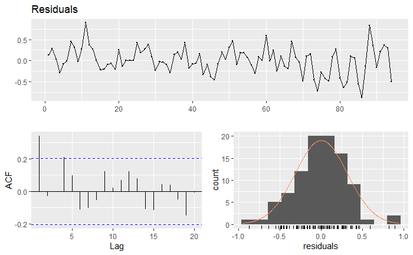

```r
checkresiduals(xmfit)
```

```r
NA
```

Looking at the summary, p-values , standard error and Adjusted R-Squared, one can tell it is a good model However, upon chekcing the residuals, the ACF plot of it is coming to be significant at some lags and the LJung test p value is also low (the test is uptil 10 lags as specified by the Breusch-Godfrey test). Thus, it can be said that there is some inormation left in the residuals

3. (5 pts) Fit a simple ARIMA model (not a dynamic regression model) to explain the training set log-of-sales-volume data. Report the diagnostic of your model’s residuals and comment on the model’s validity.

```r
arimaq3 <- auto.arima(xm.trlasso$y.tr)
print("following is an ARIMA model on training set log-of-sales ")
```

```
[1] "following is an ARIMA model on training set log-of-sales "
```

```r
print(arimaq3)
```

```
Series: xm.trlasso$y.tr
ARIMA(4,0,0) with non-zero mean

Coefficients:
         ar1      ar2     ar3      ar4    mean
      0.5945  -0.6890  0.3187  -0.1584  4.6321
s.e.  0.1021   0.1141  0.1151   0.1037  0.0701

sigma^2 estimated as 0.4211:  log likelihood=-90.62
AIC=193.25   AICc=194.21   BIC=208.51
```

```r
cat("\n")
```

```r
print("following is the residual diagnostic ")
```

```
[1] "following is the residual diagnostic "
```

```
    Ljung-Box test

data:  Residuals from ARIMA(4,0,0) with non-zero mean
Q* = 2.299, df = 5, p-value = 0.8064

Model df: 5.   Total lags used: 10


    Ljung-Box test

data:  Residuals from ARIMA(4,0,0) with non-zero mean
Q* = 2.299, df = 5, p-value = 0.8064
```

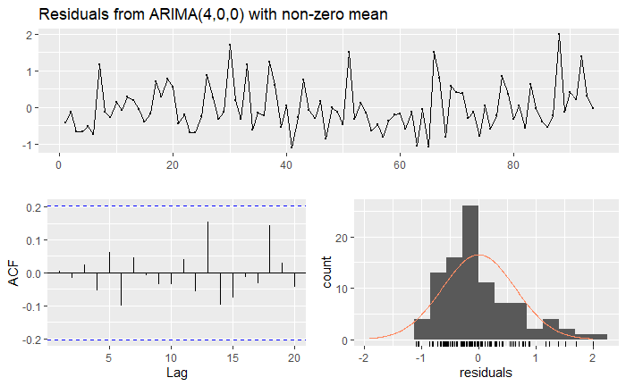

```r
print(checkresiduals(arimaq3))
```

The errors come under the intervals, indicating that they resemble the white noise and are uncorelated with each other. THe L-Jung pvalue is also > 0.05 thus, indicating that the null hypothesis of the series being stationary is true. However, the residual distribution does not display a proper normal curve and is intead skewed towards right indicating that the error residuals may not be normally distributed, thus the forecasts that will be produced by the model may be good but the prediction intervals may not be accurate

4. (5 pts) Use the model in Question 3 to prepare a 10 period ahead forecast and compare it (overly it) with the testing set log-of-sales data. Comment on the usefulness of this model in terms of precision and confidence interval.

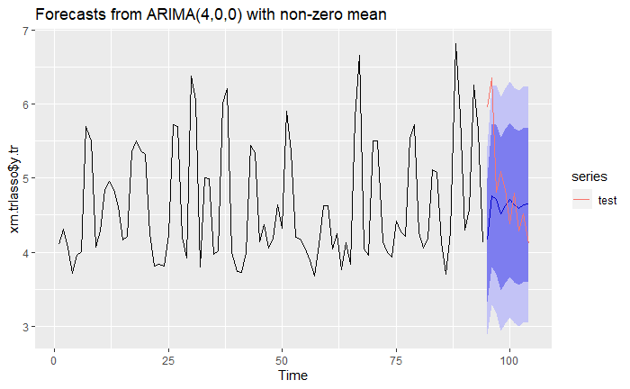

```r
trfsct <- forecast(arimaq3,h = 10)
test <- ts(y.te, start = 95)
autoplot(trfsct)+
  autolayer(test)
```

```r
NA
NA
```

The confidence intervals are straight and stationar, more of a deterministic trend - they tend to be equidistant from the point forecast. Moreover, they tend to spread a lot with respect to point forecast. Also, at starting intervals, the test points are coming out from the prediction intervals as well, suggesting the intervals of the model are not good. This is something which we also observed through the residual plots in the question above

5. (5 pts) Use the **auto.arima(…)** function to fit a dynamic regression (i.e., regression with ARIMA errors) model to explain sales data (log) using only the predictive variables identified by The Lasso in Question 1. Examine the model’s residuals and comment on its validity.

```r
xregtr <- cbind(xm.trlasso[,c('S.WD_MIN.SK')],xm.trlasso[,c('PPU.SK')])
dynreg <- auto.arima(y.tr, xreg = xregtr)

print("following are the residuals of the model")
```

```
[1] "following are the residuals of the model"
```

```
    Ljung-Box test

data:  Residuals from Regression with ARIMA(0,0,1) errors
Q* = 14.614, df = 6, p-value = 0.02348

Model df: 4.   Total lags used: 10
```

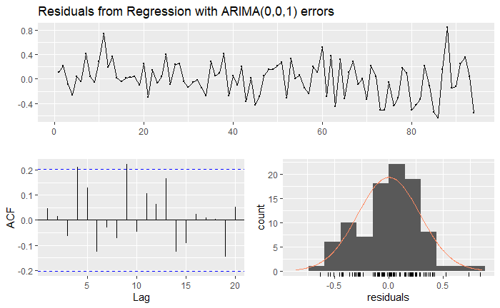

```r
checkresiduals(dynreg)
```

The p-value is less than 0.05 and the ACF plot of residuals also show significant spikes at some lags thus indicating that there is some correlation left between the errors and they are not similar to white noise

6. (5 pts) Obtain a dynamic regression model that improves on the auto-arima model in Question 5 in terms of its information coefficients and residual diagnostics. Compare the coefficients of the explanatory variables in (a) The Lasso model, (b) The unrestricted model obtained in Question 2, and (c) The ones obtained in this question. Then use the B notation (polynomial) to describe the model you obtained.

```r
print("Following is the summaryb of previous auto arima")
```

```
[1] "Following is the summaryb of previous auto arima"
```

```r
print(summary(dynreg))
```

```
Series: y.tr
Regression with ARIMA(0,0,1) errors

Coefficients:
         ma1  intercept   xreg1    xreg2
      0.5109     6.9871  0.3591  -2.6548
s.e.  0.0942     0.1340  0.0928   0.1341

sigma^2 estimated as 0.08464:  log likelihood=-15.43
AIC=40.86   AICc=41.54   BIC=53.58

Training set error measures:
                       ME      RMSE       MAE        MPE     MAPE      MASE       ACF1
Training set -0.000157446 0.2846773 0.2242023 -0.3514288 4.941856 0.3436012 0.04571852
                       ME      RMSE       MAE        MPE     MAPE      MASE       ACF1
Training set -0.000157446 0.2846773 0.2242023 -0.3514288 4.941856 0.3436012 0.04571852
```

```r
xregtr <- cbind(S.WD_MIN.SK = xm.tr[,c('S.WD_MIN.SK')],PPU.SK = xm.tr[,c('PPU.SK')])
#dynreg7 <- arima(y.tr, xreg = cbind(S.WD_MIN.SK = xm.tr[,c('S.WD_MIN.SK')],PPU.SK = xm.tr[,c('PPU.SK')]), order = c(4,0,0))
dynreg7 <- Arima(y.tr, xreg = xregtr , order = c(2,0,4))

cat("\n")
```

```r
print("Following model is found to be performing better than the previous one")
```

```
[1] "Following model is found to be performing better than the previous one"
```

```r
print(summary(dynreg7))
```

```
Series: y.tr
Regression with ARIMA(2,0,4) errors

Coefficients:
         ar1      ar2      ma1     ma2     ma3     ma4  intercept  S.WD_MIN.SK   PPU.SK
      0.8188  -0.7000  -0.3579  0.3967  0.3541  0.4066     6.9659       0.3324  -2.6330
s.e.  0.1022   0.1006   0.1269  0.1168  0.1078  0.1262     0.1084       0.0857   0.0973

sigma^2 estimated as 0.07068:  log likelihood=-6.82
AIC=33.64   AICc=36.29   BIC=59.07

Training set error measures:
                      ME      RMSE       MAE        MPE     MAPE      MASE       ACF1
Training set 0.001054865 0.2528149 0.1970648 -0.2858047 4.306248 0.3020116 0.01170804
                      ME      RMSE       MAE        MPE     MAPE      MASE       ACF1
Training set 0.001054865 0.2528149 0.1970648 -0.2858047 4.306248 0.3020116 0.01170804
```

```r
cat("\n")
```

```r
print("Checking for residuals nt of the model")
```

```
[1] "Checking for residuals nt of the model"
```

```r
cat("\n")
```

```r
print("following are the residuals of the model")
```

```
[1] "following are the residuals of the model"
```

```
    Ljung-Box test

data:  Residuals from Regression with ARIMA(2,0,4) errors
Q* = 6.2823, df = 3, p-value = 0.09865

Model df: 9.   Total lags used: 12
```

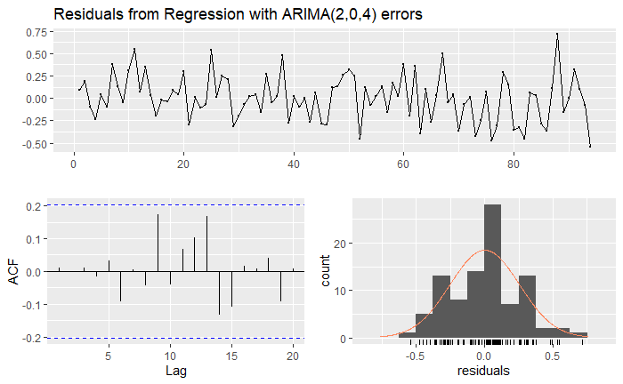

```r
checkresiduals(dynreg7)
```

The model selected above is with ARIMA(2,0,4). As you can see, it has a smaller AIC, p-value >0.05 and the distribution of residuals is more normal as compared to the previous model.

Following are the coefficients of all the three models

```
      Intercept S.WD_MIN_SK  PPU.SK
```

Lasso: Intercept 6.735034  
S.WD_MIN_SK 0.4593  
PPU.SK -2.3942

lm:  
Intercept 6.8563  
S.WD_MIN_SK 0.5741  
PPU.SK -2.5493

dynreg7: Intercept 6.9659  
S.WD_MIN_SK 0.3324  
PPU.SK -2.6330

y(t) = Intercept + 0.3324*xregtr1 - 2.6330*xregtr2 + N(t)

7. (5 pts) Use the model in Question 5 to prepare a 10 period ahead forecast and compare it (overlay it) with the testing set log-of-sales data. You can also obtain the values of the regressors used in the forecasting model from the testing data set **xm.te**. Comment on the usefulness of this model in terms of precision and confidence interval relative to the model without explanatory variables in Question 3.

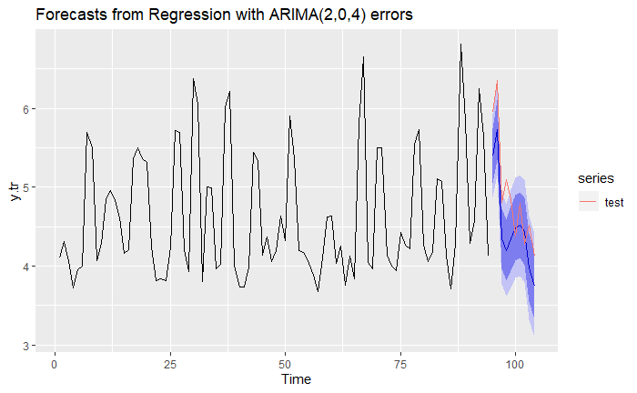

The model above is able to capture the trend, however it is lagging a bit in terms of seasonality effects. The real points is not even lying inside the prediction intervals, which is also shown by the residual plot above. However, in comparison to question 3, the external regressors are helping the series to capture the trend properly and the prediction intervals have also improved drastically. Thus, external information is helping a lot improving the model performance, precision and accuracy

8. (5 pts) After you complete a project, it is often useful to reflect on what would you do different if you were to perform this project again. This is no exception. Comment on the training and testing fit statistics and discuss how do you think you could improve on the performance of the model in terms of (a) additional data, (b) different pre-processing of the existing data, and (c) different modeling choices. Discuss your assessment of the potential for improvement (ex-ante priorities) for the different improvement options you suggest.

Additional data: - Could have incorporated holiday regressors, as people tend to shop more in holiday seasons - Information about offer periods related to various brands could have also helped forecasting better - The demographic information across the stores, i.e. the amount of people and their trends could have further added to the accuracy of the model

B). Different Pre-processing: - Can have added number of brands in the model per store - to get a sense of number of brands currently sold across stores, as inclusion of one brand may effect the sales of peanut butter. Can also try various interaction terms with it as well (for example number of brands per store). - Price changes with respect to previous month - Calculated average price per pound, but could have also included price per unit as people buy in containers generally. This information could have helped in gaining better results

C). Different modelling choices: - Could try Baysian Forecasting methods - Could try neural networks - Could also try forecasting through endogenous variables and trying different information variables